# French given names per year per department

Lucas Mello Schnorr, Jean-Marc Vincent

October, 2022

# The problem context

The aim of the activity is to develop a methodology to answer a specific question on a given dataset.

The dataset is the set of Firstname given in France on a large period of time. [https://www.insee.fr/fr/statistiques/2540004](https://www.insee.fr/fr/statistiques/fichier/2540004/dpt2021_csv.zip), we choose this dataset because it is sufficiently large, you can’t do the analysis by hand, the structure is simple

## Download Raw Data from the website

```r
# file = "dpt2021_csv.zip"
# if(!file.exists(file)){
#   download.file("https://www.insee.fr/fr/statistiques/fichier/2540004/dpt2021_csv.zip", destfile=file)
# }
#
# unzip(file)
```

## Build the Dataframe from file

```r
#library(tidyverse)

FirstNames <- read_delim("dpt2021.csv",delim=";")
```

All of these following questions may need a preliminary analysis of the data, feel free to present answers and justifications in your own order and structure your report as it should be for a scientific report.

1. Choose a firstname and analyse its frequency along time. Compare several firstnames frequency

```r
FirstNames
```

```
## # A tibble: 3,784,673 x 5
##     sexe preusuel       annais dpt   nombre
##    <dbl> <chr>           <dbl> <chr>  <dbl>
##  1     1 _PRENOMS_RARES   1900 02         7
##  2     1 _PRENOMS_RARES   1900 04         9
##  3     1 _PRENOMS_RARES   1900 05         8
##  4     1 _PRENOMS_RARES   1900 06        23
##  5     1 _PRENOMS_RARES   1900 07         9
##  6     1 _PRENOMS_RARES   1900 08         4
##  7     1 _PRENOMS_RARES   1900 09         6
##  8     1 _PRENOMS_RARES   1900 10         3
##  9     1 _PRENOMS_RARES   1900 11        11
## 10     1 _PRENOMS_RARES   1900 12         7
## # ... with 3,784,663 more rows
```

```r
yvette <- subset(FirstNames, preusuel == "YVETTE")

head(yvette)
```

```
## # A tibble: 6 x 5
##    sexe preusuel annais dpt   nombre
##   <dbl> <chr>     <dbl> <chr>  <dbl>
## 1     2 YVETTE     1900 17         8
## 2     2 YVETTE     1900 33         5
## 3     2 YVETTE     1900 47         4
## 4     2 YVETTE     1900 75         6
## 5     2 YVETTE     1900 77         3
## 6     2 YVETTE     1901 02         3
```

```r
yvette_years <- yvette %>%
  group_by(annais) %>%
  summarise(sum_counts = sum(nombre))
```

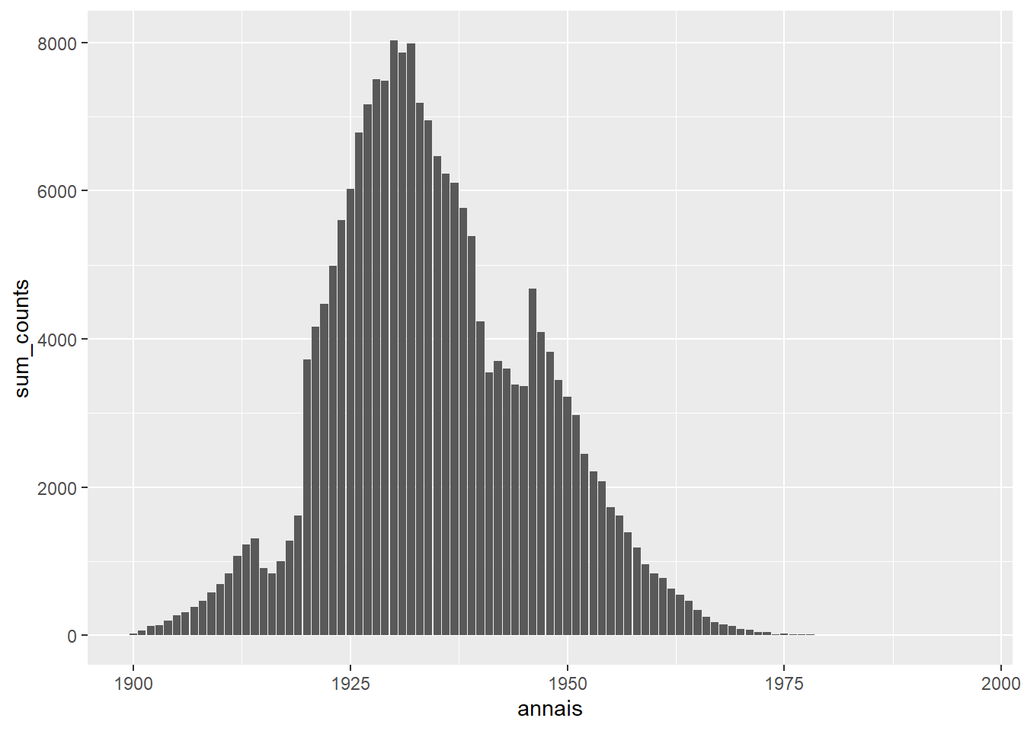

```r
yvette_years %>%
  ggplot(aes(annais, sum_counts)) +
  geom_col()
```

```r
  #geom_point()
```

```r
compare3 <- FirstNames %>%
  subset(preusuel == "YVETTE" | preusuel == "JULIA" | preusuel == "LÉONE") %>%
  group_by(preusuel, annais) %>%
  summarise(sum_counts = sum(nombre))
```

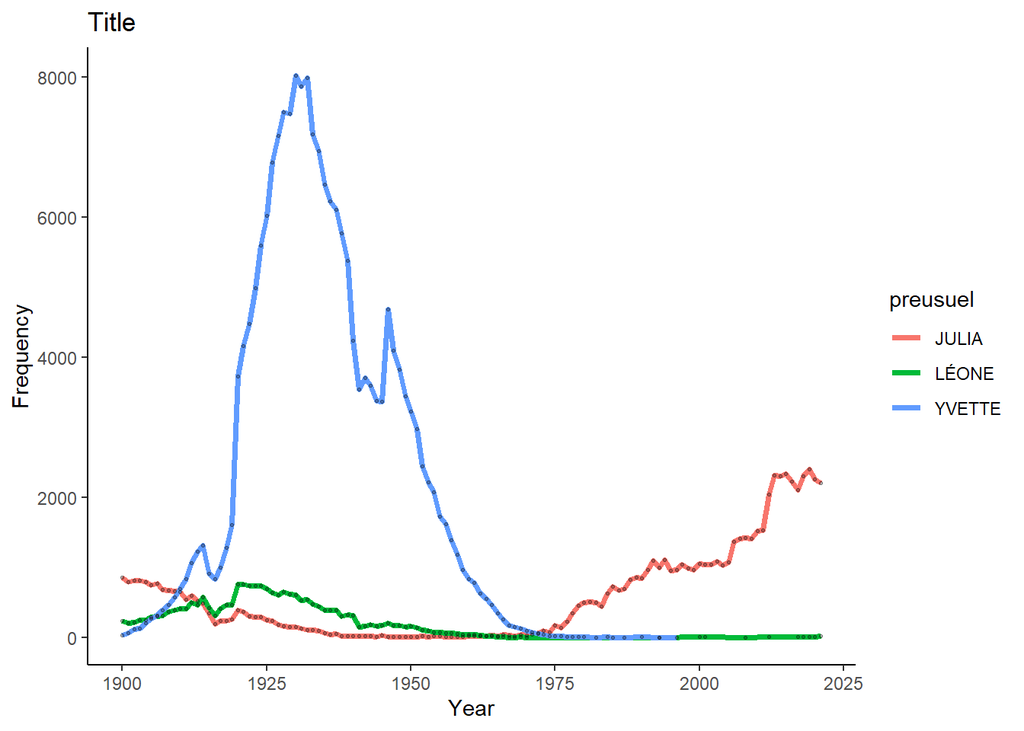

```r
# add uncertainty - 95% CI?

compare3 %>%
  ggplot(aes(annais, sum_counts)) +
  geom_line(aes(color=preusuel), size=1.3) +
  geom_point(alpha=0.3, size=0.6) +
  theme_classic() +
  labs(title = "Title",
       x     = "Year",
       y     = "Frequency",
       fill  = "First Name")
```

2. Establish by gender the most given firstname by year. Analyse the evolution of the most frequent firstname.

```r
names_sum <- FirstNames %>%
  group_by(preusuel, annais, sexe) %>%
  summarise(sum = sum(nombre))
head(names_sum)
```

```
## # A tibble: 6 x 4
## # Groups:   preusuel, annais [3]
##   preusuel       annais  sexe   sum
##   <chr>           <dbl> <dbl> <dbl>
## 1 _PRENOMS_RARES   1900     1  1221
## 2 _PRENOMS_RARES   1900     2  1713
## 3 _PRENOMS_RARES   1901     1  1326
## 4 _PRENOMS_RARES   1901     2  1768
## 5 _PRENOMS_RARES   1902     1  1315
## 6 _PRENOMS_RARES   1902     2  1741
```

```r
# top names with max freq by year

most_common <- names_sum %>%
  group_by(annais, sexe) %>%
  top_n(1, sum)


head(most_common)
```

```
## # A tibble: 6 x 4
## # Groups:   annais, sexe [6]
##   preusuel       annais  sexe   sum
##   <chr>           <dbl> <dbl> <dbl>
## 1 _PRENOMS_RARES   1991     2  8667
## 2 _PRENOMS_RARES   1992     2  9110
## 3 _PRENOMS_RARES   1993     2  9651
## 4 _PRENOMS_RARES   1994     2  9853
## 5 _PRENOMS_RARES   1995     1  9768
## 6 _PRENOMS_RARES   1995     2 10287
```

```r
most_common$sexe <-  factor(most_common$sexe) #change for plot
```

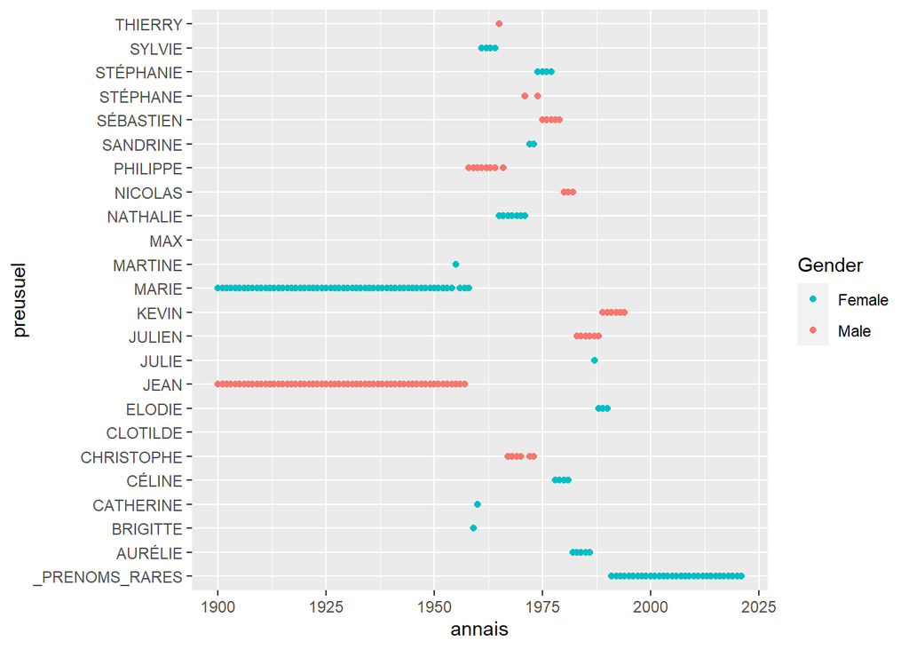

```r
# most common name by gender

most_common %>%
  ggplot(aes(annais, preusuel, color=sexe)) +
  geom_point() +
  scale_color_discrete(name  ="Gender",
                          breaks=c("2", "1"),
                          labels=c("Female", "Male"))
```

3. Optional : Which department has a larger variety of names along time ? Is there some sort of geographical correlation with the data?

```r
# make most common by department

most_common_bydept <- FirstNames %>%
  group_by(preusuel, annais, sexe, dpt) %>%
  summarise(sum = sum(nombre)) %>%
  top_n(1, sum)
most_common_bydept
```

```
## # A tibble: 344,618 x 5
## # Groups:   preusuel, annais, sexe [303,019]
##    preusuel       annais  sexe dpt     sum
##    <chr>           <dbl> <dbl> <chr> <dbl>
##  1 _PRENOMS_RARES   1900     1 971     180
##  2 _PRENOMS_RARES   1900     2 971     205
##  3 _PRENOMS_RARES   1901     1 971     182
##  4 _PRENOMS_RARES   1901     2 971     206
##  5 _PRENOMS_RARES   1902     1 971     189
##  6 _PRENOMS_RARES   1902     2 971     208
##  7 _PRENOMS_RARES   1903     1 971     162
##  8 _PRENOMS_RARES   1903     2 971     196
##  9 _PRENOMS_RARES   1904     1 971     204
## 10 _PRENOMS_RARES   1904     2 971     188
## # ... with 344,608 more rows
```

```r
# most_common_bydept %>%
#   ggplot(aes(annais, preusuel, color=sexe)) +
#   geom_point() +
#   facet_wrap(~dpt, ncol = 2)
#
```

```r
# most_common_bydept %>%
#   ggplot(aes(annais, preusuel, color=dpt)) +
#   geom_point()
```